# Data Timeliness as an Evaluation Metric

2023-08-21

# Calculating Data Timeliness

For most trips, I calculated data timeliness as the time between a trip ending and data being available to the Catch Accounting System. For trawl EM, I used offload end date instead of trip end date, as I was unable to link trip end date to trawl EM offloads. I used the time at which data were available to the CAS, rather than the time at which data were submitted to the AFSC, as I could measure the former more consistently across EM and observed strata. I used data from 2022 to calculate stratum-specific data timeliness. Trips from which data were not available were excluded. Dashed red lines and their associated annotations show mean data timeliness for each stratum:

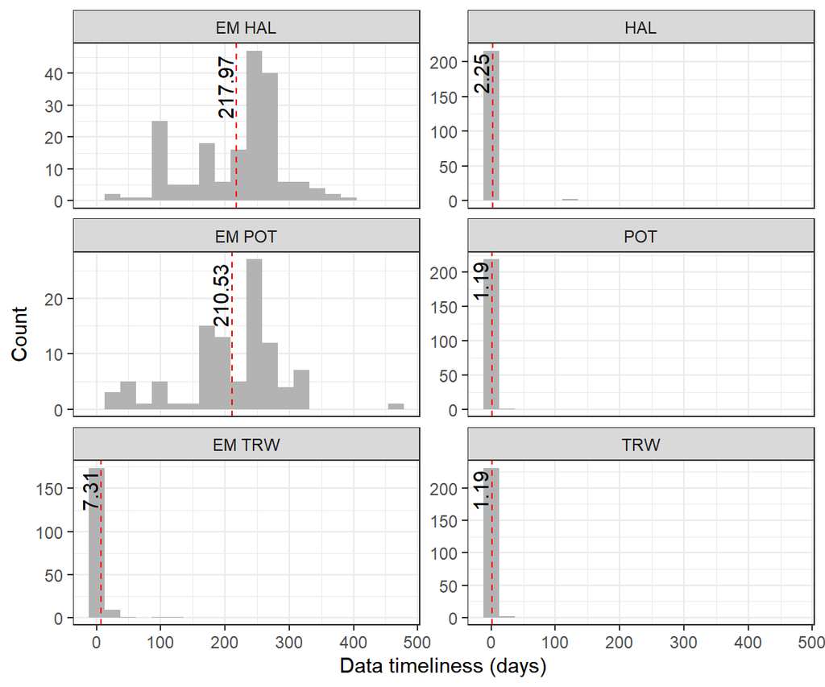

# Creating a Function

I created a function that uses stratum-specific mean data timeliness to estimate the mean data timeliness of all (monitored and unmonitored) non-jig trips within a data set.

```
##    COVERAGE_TYPE     STRATA mean_data_timeliness
## 1:          FULL EM_TRW_EFP                 7.88
## 2:          FULL       FULL                 0.31
## 3:       PARTIAL     EM_HAL               217.97
## 4:       PARTIAL     EM_POT               210.53
## 5:       PARTIAL EM_TRW_EFP                 7.31
## 6:       PARTIAL        HAL                 2.25
## 7:       PARTIAL        POT                 1.19
## 8:       PARTIAL        TRW                 1.19
```

Unmonitored trips receive the same timeliness as monitored trips within a stratum, since data from monitored trips will be used to generate estimates for unmonitored trips. As an example, the function estimates a mean data timeliness of 26.68 days for all non-jig trips that occurred in 2022:

```r
evaluate_data_timeliness(data, strata_timeliness)
```

```
## [1] 26.68
```

This can be compared to a design in which data from fixed-gear EM strata are available in half the time it currently takes them to reach CAS:

```r
evaluate_data_timeliness(data, copy(strata_timeliness)[STRATA %in% c("EM_HAL", "EM_POT"), mean_data_timeliness := round(mean_data_timeliness/2, 2)])
```

```
## [1] 14.48
```

Or we could choose to return mean data timeliness for partial coverage strata only:

```r
evaluate_data_timeliness(data[COVERAGE_TYPE == "PARTIAL"], strata_timeliness)
```

```
## [1] 36.18
```